# The Generalised Linear Model (2)

PSM 2

Bennett Kleinberg

22 Jan 2019

## Welcome

Probability, Statistics & Modeling II

### Lecture 3

GLM 2

### What question do you have?

## Today

- Recap linear regression
- Why the GLM?
- Extended cases: logistic regression
- How good is the model?
- How does one model compare to another?

## Recap linear regression

### Ingredients?

## Recap linear regression

### Core idea?

## Recap linear regression

### Types of effects?

## Recap linear regression

### Residuals?

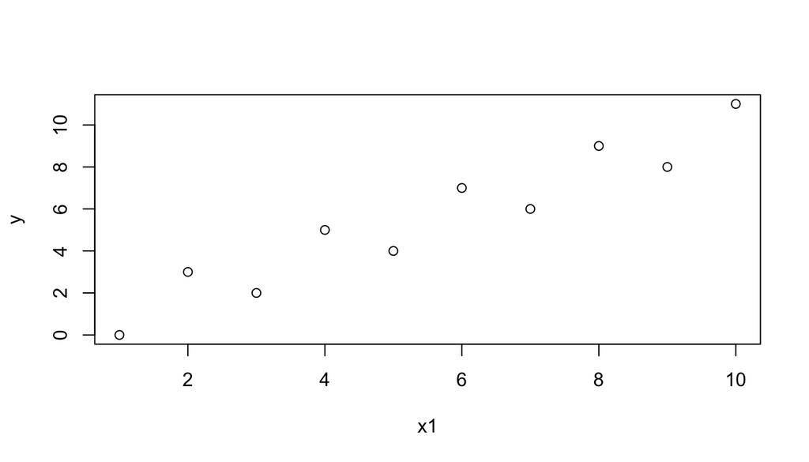

```r
x1 = 1:10
y = x1 + rep(c(-1, 1))
df = data.frame(x1, y)
plot(x1, y)
```

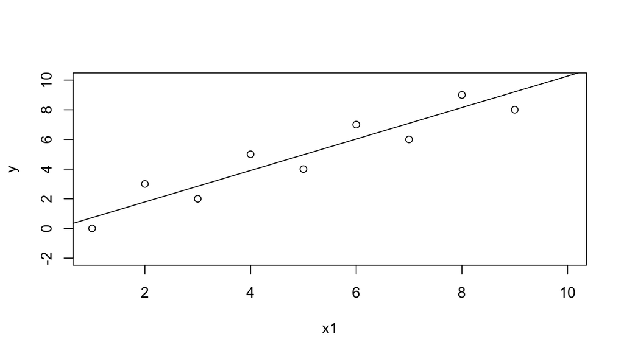

```r
lm_1 = lm(y ~ x1, data=df)
{plot(x1, y, ylim=c(-2, 10))
  abline(lm_1)}
```

### Continuation from last week

How to find the “optimal” terms for my model?

## Maybe we can optimise this?

What if you don’t know what the ‘ideal’ model is?

*Especially neat for predictive modelling*

**Back to the shooting data:**

```r
load('./data/mass_shootings_detailed.RData')
smsd = smsd[smsd$school_related != 'Killed', ]
smsd = droplevels(smsd)
names(smsd)
```

```
##  [1] "caseid"         "n_fatal"        "n_injured"      "date"
##  [5] "day"            "age"            "gender"         "n_guns"
##  [9] "school_related" "mental_illness"
```

## Automated variable selection

1. Specify the complete model

```r
complete_model = lm(n_fatal ~ n_guns*mental_illness*school_related, data = smsd)
```

2. Specify the null model

```r
null_model = lm(n_fatal ~ 1, data = smsd)
```

3. Run model selection …

3 predictor variables: how many terms in the model?

- 1 intercept
- 3 main effects
- 3 2-way interactions
- 1 3-way interaction

## Model selection

```r
summary(complete_model)
```

```
##
## Call:
## lm(formula = n_fatal ~ n_guns * mental_illness * school_related,
##     data = smsd)
##
## Residuals:
##     Min      1Q  Median      3Q     Max
## -6.9592 -2.1233 -0.6777  1.2421 26.2074
##
## Coefficients:
##                                            Estimate Std. Error t value
## (Intercept)                                 2.30041    0.93210   2.468
## n_guns                                      0.86436    0.39577   2.184
## mental_illnessYes                           1.47991    1.28991   1.147
## school_relatedYes                          -0.01274    1.70127  -0.007
## n_guns:mental_illnessYes                    0.03300    0.49495   0.067
## n_guns:school_relatedYes                   -1.02874    0.77367  -1.330
## mental_illnessYes:school_relatedYes        -3.41734    2.24208  -1.524
## n_guns:mental_illnessYes:school_relatedYes  1.94549    0.91794   2.119
##                                            Pr(>|t|)
## (Intercept)                                  0.0146 *
## n_guns                                       0.0303 *
## mental_illnessYes                            0.2528
## school_relatedYes                            0.9940
## n_guns:mental_illnessYes                     0.9469
## n_guns:school_relatedYes                     0.1854
## mental_illnessYes:school_relatedYes          0.1293
## n_guns:mental_illnessYes:school_relatedYes   0.0355 *
## ---
## Signif. codes:  0 '***' 0.001 '**' 0.01 '*' 0.05 '.' 0.1 ' ' 1
##
## Residual standard error: 4.016 on 173 degrees of freedom
## Multiple R-squared:  0.2315, Adjusted R-squared:  0.2004
## F-statistic: 7.444 on 7 and 173 DF,  p-value: 8.021e-08
```

## Model selection

```r
summary(null_model)
```

```
##
## Call:
## lm(formula = n_fatal ~ 1, data = smsd)
##
## Residuals:
##     Min      1Q  Median      3Q     Max
## -4.4751 -2.4751 -0.4751  1.5249 27.5249
##
## Coefficients:
##             Estimate Std. Error t value Pr(>|t|)
## (Intercept)   4.4751     0.3338    13.4   <2e-16 ***
## ---
## Signif. codes:  0 '***' 0.001 '**' 0.01 '*' 0.05 '.' 0.1 ' ' 1
##
## Residual standard error: 4.491 on 180 degrees of freedom
```

## Model selection: backward

```r
step(complete_model, direction = 'backward')
```

```
## Start:  AIC=511.13
## n_fatal ~ n_guns * mental_illness * school_related
##
##                                        Df Sum of Sq    RSS    AIC
## <none>                                              2790.6 511.13
## - n_guns:mental_illness:school_related  1    72.456 2863.0 513.77
```

```
##
## Call:
## lm(formula = n_fatal ~ n_guns * mental_illness * school_related,
##     data = smsd)
##
## Coefficients:
##                                (Intercept)
##                                    2.30041
##                                     n_guns
##                                    0.86436
##                          mental_illnessYes
##                                    1.47991
##                          school_relatedYes
##                                   -0.01274
##                   n_guns:mental_illnessYes
##                                    0.03300
##                   n_guns:school_relatedYes
##                                   -1.02874
##        mental_illnessYes:school_relatedYes
##                                   -3.41734
## n_guns:mental_illnessYes:school_relatedYes
##                                    1.94549
```

## Model selection: forward

```r
step(null_model, direction = 'forward'
     , scope=list(lower=null_model, upper=complete_model))
```

```
## Start:  AIC=544.78
## n_fatal ~ 1
##
##                  Df Sum of Sq    RSS    AIC
## + n_guns          1    535.46 3095.7 517.91
## + mental_illness  1    174.44 3456.7 537.87
## + school_related  1     55.94 3575.2 543.97
## <none>                        3631.1 544.78
##
## Step:  AIC=517.91
## n_fatal ~ n_guns
##
##                  Df Sum of Sq    RSS    AIC
## + mental_illness  1    95.460 3000.2 514.24
## + school_related  1    57.394 3038.3 516.52
## <none>                        3095.7 517.91
##
## Step:  AIC=514.24
## n_fatal ~ n_guns + mental_illness
##
##                         Df Sum of Sq    RSS    AIC
## + school_related         1    84.677 2915.5 511.06
## <none>                               3000.2 514.24
## + n_guns:mental_illness  1    30.943 2969.3 514.36
##
## Step:  AIC=511.06
## n_fatal ~ n_guns + mental_illness + school_related
##
##                                 Df Sum of Sq    RSS    AIC
## + n_guns:mental_illness          1    36.664 2878.9 510.77
## <none>                                       2915.5 511.06
## + n_guns:school_related          1    18.227 2897.3 511.92
## + mental_illness:school_related  1     3.208 2912.3 512.86
##
## Step:  AIC=510.77
## n_fatal ~ n_guns + mental_illness + school_related + n_guns:mental_illness
##
##                                 Df Sum of Sq    RSS    AIC
## <none>                                       2878.9 510.77
## + n_guns:school_related          1    13.979 2864.9 511.88
## + mental_illness:school_related  1     4.243 2874.6 512.50
```

```
##
## Call:
## lm(formula = n_fatal ~ n_guns + mental_illness + school_related +
##     n_guns:mental_illness, data = smsd)
##
## Coefficients:
##              (Intercept)                    n_guns
##                   2.7122                    0.6060
##        mental_illnessYes         school_relatedYes
##                   0.3975                   -1.5038
## n_guns:mental_illnessYes
##                   0.6247
```

## Limitations of linear regression?

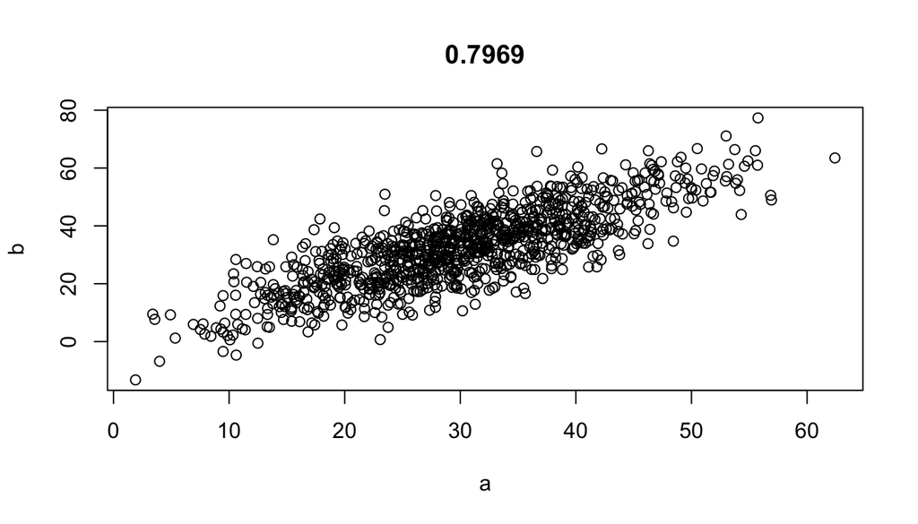

```r
set.seed(123)
a = rnorm(1000, 30, 10)
b = a + rnorm(1000, 2, 8)
plot(a, b, main = round(cor(a, b), 4))
```

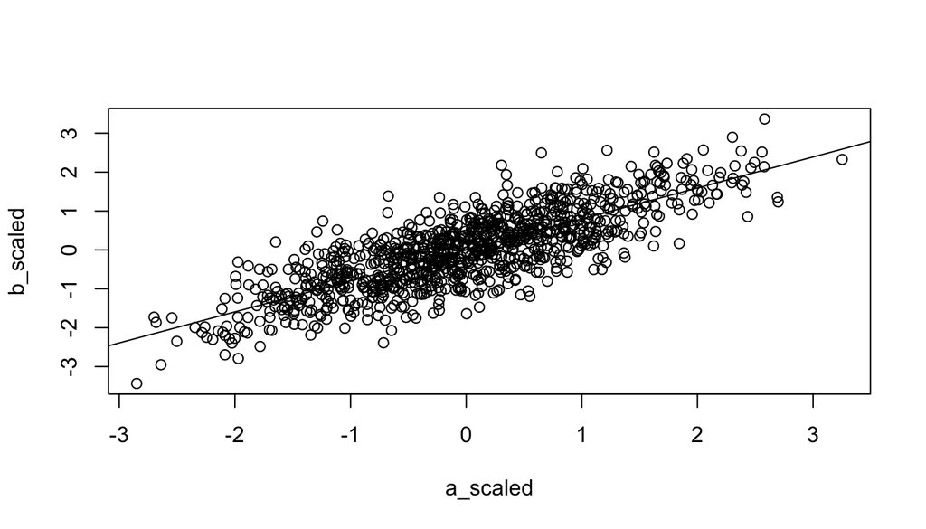

```r
a_scaled = scale(a)
b_scaled = scale(b)
{plot(a_scaled, b_scaled)
abline(lm(a_scaled ~ b_scaled))}
```

```r
lm(a_scaled ~ b_scaled - 1)
```

```
##
## Call:
## lm(formula = a_scaled ~ b_scaled - 1)
##
## Coefficients:
## b_scaled
##   0.7969
```

## Limitations of linear regression?

- Correlation != causation
- **Continuous outcome variable**

## Generalising the model

### The Generalised Linear Model

## GLM in general

- framework to deal with different outcome variables
- uses the same “linearity in parameters” idea
- key feature: linking the outcome to the predictor(s)

## The GLM in R

```r
my_model_glm = glm(formula = n_fatal ~ n_guns*mental_illness*school_related
               , family = gaussian
               , data = smsd)
summary(my_model_glm)
```

```
##
## Call:
## glm(formula = n_fatal ~ n_guns * mental_illness * school_related,
##     family = gaussian, data = smsd)
##
## Deviance Residuals:
##     Min       1Q   Median       3Q      Max
## -6.9592  -2.1233  -0.6777   1.2421  26.2074
##
## Coefficients:
##                                            Estimate Std. Error t value
## (Intercept)                                 2.30041    0.93210   2.468
## n_guns                                      0.86436    0.39577   2.184
## mental_illnessYes                           1.47991    1.28991   1.147
## school_relatedYes                          -0.01274    1.70127  -0.007
## n_guns:mental_illnessYes                    0.03300    0.49495   0.067
## n_guns:school_relatedYes                   -1.02874    0.77367  -1.330
## mental_illnessYes:school_relatedYes        -3.41734    2.24208  -1.524
## n_guns:mental_illnessYes:school_relatedYes  1.94549    0.91794   2.119
##                                            Pr(>|t|)
## (Intercept)                                  0.0146 *
## n_guns                                       0.0303 *
## mental_illnessYes                            0.2528
## school_relatedYes                            0.9940
## n_guns:mental_illnessYes                     0.9469
## n_guns:school_relatedYes                     0.1854
## mental_illnessYes:school_relatedYes          0.1293
## n_guns:mental_illnessYes:school_relatedYes   0.0355 *
## ---
## Signif. codes:  0 '***' 0.001 '**' 0.01 '*' 0.05 '.' 0.1 ' ' 1
##
## (Dispersion parameter for gaussian family taken to be 16.13046)
##
##     Null deviance: 3631.1  on 180  degrees of freedom
## Residual deviance: 2790.6  on 173  degrees of freedom
## AIC: 1026.8
##
## Number of Fisher Scoring iterations: 2
```

## Compared to `lm`

```r
my_model_lm = lm(formula = n_fatal ~ n_guns*mental_illness*school_related
               , data = smsd)
summary(my_model_lm)
```

```
##
## Call:
## lm(formula = n_fatal ~ n_guns * mental_illness * school_related,
##     data = smsd)
##
## Residuals:
##     Min      1Q  Median      3Q     Max
## -6.9592 -2.1233 -0.6777  1.2421 26.2074
##
## Coefficients:
##                                            Estimate Std. Error t value
## (Intercept)                                 2.30041    0.93210   2.468
## n_guns                                      0.86436    0.39577   2.184
## mental_illnessYes                           1.47991    1.28991   1.147
## school_relatedYes                          -0.01274    1.70127  -0.007
## n_guns:mental_illnessYes                    0.03300    0.49495   0.067
## n_guns:school_relatedYes                   -1.02874    0.77367  -1.330
## mental_illnessYes:school_relatedYes        -3.41734    2.24208  -1.524
## n_guns:mental_illnessYes:school_relatedYes  1.94549    0.91794   2.119
##                                            Pr(>|t|)
## (Intercept)                                  0.0146 *
## n_guns                                       0.0303 *
## mental_illnessYes                            0.2528
## school_relatedYes                            0.9940
## n_guns:mental_illnessYes                     0.9469
## n_guns:school_relatedYes                     0.1854
## mental_illnessYes:school_relatedYes          0.1293
## n_guns:mental_illnessYes:school_relatedYes   0.0355 *
## ---
## Signif. codes:  0 '***' 0.001 '**' 0.01 '*' 0.05 '.' 0.1 ' ' 1
##
## Residual standard error: 4.016 on 173 degrees of freedom
## Multiple R-squared:  0.2315, Adjusted R-squared:  0.2004
## F-statistic: 7.444 on 7 and 173 DF,  p-value: 8.021e-08
```

## GLM vs LM

The LM is a GLM with the Gaussian link function.

- link function ‘links’ the linear predictor to the mean of the distribution of the outcome variable
- e.g. if outcome variable from normal distribution –> “normal” link function (Gaussian)
- e.g. if outcome variable from poisson distribution –> “Poisson” link (Log)
- e.g. if outcome variable from binomial distributiob –> “Binomial” link (Logit)

## Why bother with this?

Compare:

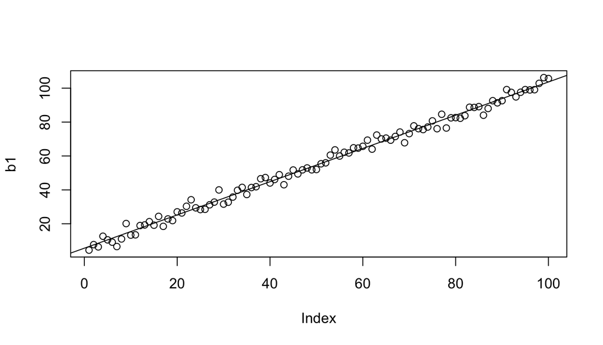

```r
b1 = 1:100 + rnorm(100, 5, 3)
df1 = data.frame(a1 = 1:100, b1)
{plot(b1)
  abline(lm(b1 ~a1, data=df1))}
```

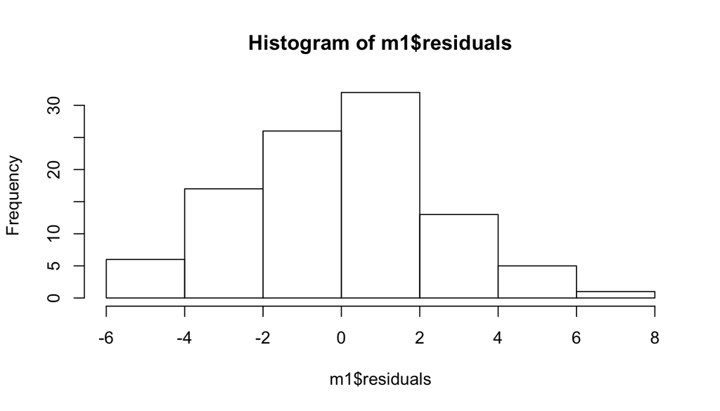

```r
m1 = lm(b1 ~a1, data=df1)
hist(m1$residuals)
```

## Why bother with this?

Compare:

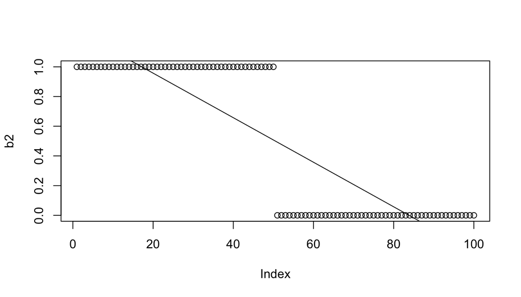

```r
b2 = rep(c(1,0), each=50)
df2 = data.frame(a2 = 1:100, b2)
{plot(b2)
  abline(lm(b2 ~a2, data=df2))}
```

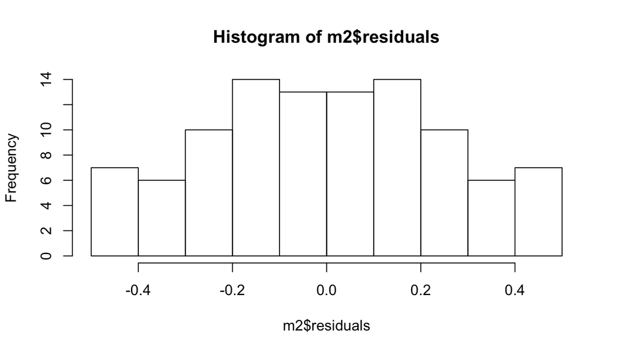

```r
m2 = lm(b2 ~a2, data=df2)
hist(m2$residuals)
```

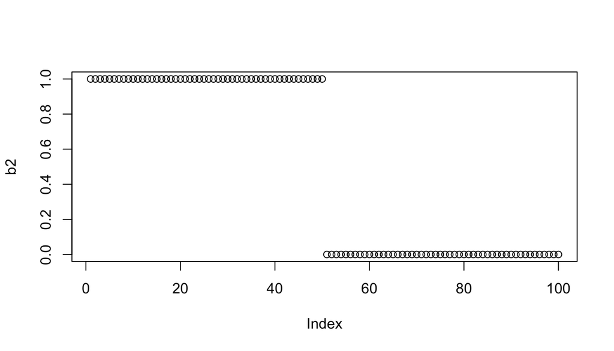

```r
plot(b2)
```

## What to do?

We need a representation of the outcome variable…

- that is linear to the predictor
- i.e. transforms the data to so that Y has a linear relationship to the predictors

*But which function does this?*

## The link function

Answer: for binary outcomes, the **logit** function

- transforms the outcome to a continuous probability
- and uses the log-odds to model a linear relationship between X and Y

## The logit function

- maps `0,1` values to `-Inf : Inf`
- assumes a probability of `P(Y == 1)`
- probability is expressed as the odds
- linearity through the log of the odds

```r
prob = 0.40
odds = prob/(1-prob)
odds
```

```
## [1] 0.6666667
```

```r
log(odds)
```

```
## [1] -0.4054651
```

## Intermezzo: odds

|  | Smoker | Nonsmoker |
| --- | --- | --- |
| Dead | 30 | 20 |
| Alive | 70 | 80 |
|  | 100 | 100 |

```r
#Odds of smoker dead:
(30/100)/(70/100)
```

```
## [1] 0.4285714
```

```r
# equal to
30/70
```

```
## [1] 0.4285714
```

## Intermezzo: odds

Odds = event_present/event_not_present

–>

```r
odds = P/(1-P)
```

## Intermezzo: odds

|  | Smoker | Nonsmoker |
| --- | --- | --- |
| Dead | 30 | 20 |
| Alive | 70 | 80 |
|  | 100 | 100 |

Odds of nonsmoker alive?

## Intermezzo: odds

|  | Smoker | Nonsmoker |
| --- | --- | --- |
| Dead | 30 | 20 |
| Alive | 70 | 80 |
|  | 100 | 100 |

```r
#Odds of nonsmoker alive:
80/20
```

```
## [1] 4
```

## Intermezzo: odds

|  | Smoker | Nonsmoker |
| --- | --- | --- |
| Dead | 30 | 20 |
| Alive | 70 | 80 |
|  | 100 | 100 |

Odds of nonsmoker alive dead?

## Intermezzo: odds

|  | Smoker | Nonsmoker |
| --- | --- | --- |
| Dead | 30 | 20 |
| Alive | 70 | 80 |
|  | 100 | 100 |

Odds of nonsmoker alive dead?

```r
20/80
```

```
## [1] 0.25
```

```r
1/(80/20)
```

```
## [1] 0.25
```

## Intermezzo: odds

|  | Smoker | Nonsmoker |
| --- | --- | --- |
| Dead | 30 | 20 |
| Alive | 70 | 80 |
|  | 100 | 100 |

Odds ratio: association between both factors.

```r
OR = (30/70)/(20/80)
OR
```

```
## [1] 1.714286
```

## The logit function

Models the binary outcome through the log odds of the predictors.

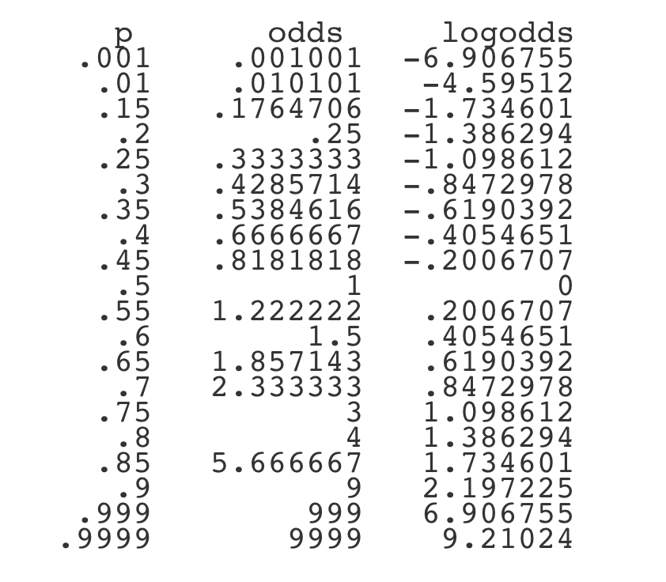

Implication: transformation of the coefficients

**Remeber: we model the log of the odds ratio.**

## The logit function

Implication: transformation of the coefficients

**Remeber: we model the log of the odds ratio.**

So we need to ‘unlog’ the coefficients to get the odds.

## Case today: Parole data

Dataset from [Kaggle](https://www.kaggle.com/parole-hearing-data/parole-hearings-in-new-york-state/version/1).

```r
load('./data/parole_data.RData')
parole_data
```

```
##          sex     race granted
## 1       MALE    WHITE       1
## 2       MALE HISPANIC       0
## 3       MALE    BLACK       0
## 4       MALE    BLACK       1
## 5       MALE HISPANIC       0
## 6       MALE HISPANIC       1
## 7       MALE    BLACK       0
## 8       MALE    WHITE       0
## 9       MALE    WHITE       0
## 10      MALE HISPANIC       0
## 11      MALE    WHITE       1
## 12      MALE    BLACK       1
## 13      MALE    BLACK       0
## 14      MALE HISPANIC       1
```

[output cut: 33320 more lines]

Suppose we model the success of parole hearings…

```r
parole_success = glm(granted ~ sex
                     , data=parole_data
                     , family = 'binomial')
parole_success
```

```
##
## Call:  glm(formula = granted ~ sex, family = "binomial", data = parole_data)
##
## Coefficients:
## (Intercept)      sexMALE
##       2.392       -1.363
##
## Degrees of Freedom: 41534 Total (i.e. Null);  41533 Residual
## Null Deviance:       46850
## Residual Deviance: 46320     AIC: 46320
```

```r
summary(parole_success)
```

```
##
## Call:
## glm(formula = granted ~ sex, family = "binomial", data = parole_data)
##
## Deviance Residuals:
##     Min       1Q   Median       3Q      Max
## -2.2268  -1.6337   0.7818   0.7818   0.7818
##
## Coefficients:
##             Estimate Std. Error z value Pr(>|z|)
## (Intercept)  2.39190    0.06916   34.58   <2e-16 ***
## sexMALE     -1.36305    0.07011  -19.44   <2e-16 ***
## ---
## Signif. codes:  0 '***' 0.001 '**' 0.01 '*' 0.05 '.' 0.1 ' ' 1
##
## (Dispersion parameter for binomial family taken to be 1)
##
##     Null deviance: 46854  on 41534  degrees of freedom
## Residual deviance: 46319  on 41533  degrees of freedom
## AIC: 46323
##
## Number of Fisher Scoring iterations: 4
```

## What does this mean?

```r
coefficients(parole_success)
```

```
## (Intercept)     sexMALE
##    2.391896   -1.363046
```

**What would the lm interpretation be?**

## Coefficient interpretation

Remember what the logit function does?

```r
Y ~ log_odds_ratio(X)
```

… So the coefficient `X` needs to be transformed.

## Coefficient interpretation

Transforming the coefficient:

**log odds** to **probability**

- **log** –> un-log
  - natural logarithm reverse
  - `e` —> `exp()` in R

## Coefficient interpretation

Let’s use the output and transform:

```r
coefficients(parole_success)
```

```
## (Intercept)     sexMALE
##    2.391896   -1.363046
```

```r
exp(-1.36)
```

```
## [1] 0.2566608
```

## Understanding the odds

```r
table(parole_data$granted, parole_data$sex)
```

```
##
##     FEMALE  MALE
##   0    228 10220
##   1   2493 28594
```

## Odds by hand

|  | Female | Male |
| --- | --- | --- |
| 0 | 228 | 10220 |
| 1 | 2493 | 28594 |
|  | 2721 | 38814 |

Odds of male granted:

```r
(28594/38814)/(10220/38814)
```

```
## [1] 2.797847
```

```r
#Note: equivalent to 28594/10220
```

Odds of female granted:

```r
2493/228
```

```
## [1] 10.93421
```

## Odds ratio male to female granted

```r
2.7978/10.9342
```

```
## [1] 0.2558761
```

Proof:

```r
log(0.2558)
```

```
## [1] -1.363359
```

```r
coefficients(parole_success)
```

```
## (Intercept)     sexMALE
##    2.391896   -1.363046
```

## Interpretation

Conversely: Female to male odds ration…

```r
10.9342/2.7978
```

```
## [1] 3.908142
```

> The odds of being granted parole as a female are 3.90 times the odds of being granted parole as a male.

## Add additional factor?

```r
tapply(parole_data$granted, list(parole_data$race), mean)
```

```
##     BLACK  HISPANIC     WHITE
## 0.6965374 0.7137377 0.8355549
```

## Extend the model

```r
parole_success_2 = glm(granted ~ sex + race
                     , data=parole_data
                     , family = 'binomial')
summary(parole_success_2)
```

```
##
## Call:
## glm(formula = granted ~ sex + race, family = "binomial", data = parole_data)
##
## Deviance Residuals:
##     Min       1Q   Median       3Q      Max
## -2.3921  -1.5223   0.6224   0.8680   0.8680
##
## Coefficients:
##              Estimate Std. Error z value Pr(>|z|)
## (Intercept)   2.04089    0.07057  28.920  < 2e-16 ***
## sexMALE      -1.25900    0.07054 -17.848  < 2e-16 ***
## raceHISPANIC  0.09646    0.02909   3.317 0.000911 ***
## raceWHITE     0.76131    0.02763  27.557  < 2e-16 ***
## ---
## Signif. codes:  0 '***' 0.001 '**' 0.01 '*' 0.05 '.' 0.1 ' ' 1
##
## (Dispersion parameter for binomial family taken to be 1)
##
##     Null deviance: 46854  on 41534  degrees of freedom
## Residual deviance: 45471  on 41531  degrees of freedom
## AIC: 45479
##
## Number of Fisher Scoring iterations: 4
```

## Interpretation

```r
coefficients(parole_success_2)
```

```
##  (Intercept)      sexMALE raceHISPANIC    raceWHITE
##   2.04089495  -1.25900315   0.09646174   0.76131449
```

**???**

–> Key: odds ratio to reference group

## Interpretation

```r
# --> sex: MALE to FEMALE
exp(-1.259)
```

```
## [1] 0.2839378
```

```r
# --> race: HISPANIC to BLACK
exp(0.096)
```

```
## [1] 1.100759
```

```r
# --> race: WHITE to BLACK
exp(0.7613)
```

```
## [1] 2.141058
```

## Adding more…

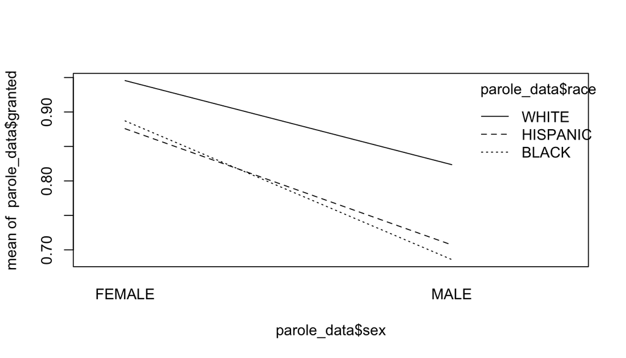

```r
interaction.plot(parole_data$sex, parole_data$race, parole_data$granted)
```

## Interactions?

```r
tapply(parole_data$granted, list(parole_data$sex, parole_data$race), mean)
```

```
##            BLACK  HISPANIC     WHITE
## FEMALE 0.8870804 0.8757764 0.9456215
## MALE   0.6859737 0.7072319 0.8236240
```

## Extend the model further

```r
parole_success_3 = glm(granted ~ sex*race
                     , data=parole_data
                     , family = 'binomial')
parole_success_3
```

```
##
## Call:  glm(formula = granted ~ sex * race, family = "binomial", data = parole_data)
##
## Coefficients:
##          (Intercept)               sexMALE          raceHISPANIC
##              2.06126              -1.27990              -0.10823
##            raceWHITE  sexMALE:raceHISPANIC     sexMALE:raceWHITE
##              0.79461               0.20885              -0.03488
##
## Degrees of Freedom: 41534 Total (i.e. Null);  41529 Residual
## Null Deviance:       46850
## Residual Deviance: 45470     AIC: 45480
```

## Interpretation

```r
coefficients(parole_success_3)
```

```
##          (Intercept)              sexMALE         raceHISPANIC
##           2.06125922          -1.27989659          -0.10823161
##            raceWHITE sexMALE:raceHISPANIC    sexMALE:raceWHITE
##           0.79461370           0.20884686          -0.03488046
```

Have a look at [this Stackexchange answer](https://stats.stackexchange.com/a/57052).

## Interpretation

```r
exp(coefficients(parole_success_3))
```

```
##          (Intercept)              sexMALE         raceHISPANIC
##            7.8558559            0.2780661            0.8974197
##            raceWHITE sexMALE:raceHISPANIC    sexMALE:raceWHITE
##            2.2135857            1.2322563            0.9657208
```

Odds ratios!

> For males the OR of BLACK to HISPANIC is 1.23 the OR of females

```r
exp(coefficients(parole_success_3))
```

```
##          (Intercept)              sexMALE         raceHISPANIC
##            7.8558559            0.2780661            0.8974197
##            raceWHITE sexMALE:raceHISPANIC    sexMALE:raceWHITE
##            2.2135857            1.2322563            0.9657208
```

Odds ratios!

> For males the OR of BLACK to WHITE is 0.97 the OR of females

```r
exp(coefficients(parole_success_3))
```

```
##          (Intercept)              sexMALE         raceHISPANIC
##            7.8558559            0.2780661            0.8974197
##            raceWHITE sexMALE:raceHISPANIC    sexMALE:raceWHITE
##            2.2135857            1.2322563            0.9657208
```

Odds ratios!

> For males the OR of granted parole is 0.27 the OR of females

```r
exp(coefficients(parole_success_3))
```

```
##          (Intercept)              sexMALE         raceHISPANIC
##            7.8558559            0.2780661            0.8974197
##            raceWHITE sexMALE:raceHISPANIC    sexMALE:raceWHITE
##            2.2135857            1.2322563            0.9657208
```

Odds ratios!

> For WHITE defendants the OR of granted parole is 2.21 the OR of BLACK defendants

## Connections to machine learning

- Regression the best starting point
- Core difference: explanatory modelling vs predictive modelling
- More care against overfitting in predictive modelling
- Split the data

### Goodness-of-fit of a model

Assessing how good a model is

## Model fit

## Model fit

**Explained variance:** R-squared [(multiple vs adjusted)](http://blog.minitab.com/blog/adventures-in-statistics-2/multiple-regession-analysis-use-adjusted-r-squared-and-predicted-r-squared-to-include-the-correct-number-of-variables)

```r
summary(complete_model)
```

```
##
## Call:
## lm(formula = n_fatal ~ n_guns * mental_illness * school_related,
##     data = smsd)
##
## Residuals:
##     Min      1Q  Median      3Q     Max
## -6.9592 -2.1233 -0.6777  1.2421 26.2074
##
## Coefficients:
##                                            Estimate Std. Error t value
## (Intercept)                                 2.30041    0.93210   2.468
## n_guns                                      0.86436    0.39577   2.184
## mental_illnessYes                           1.47991    1.28991   1.147
## school_relatedYes                          -0.01274    1.70127  -0.007
## n_guns:mental_illnessYes                    0.03300    0.49495   0.067
## n_guns:school_relatedYes                   -1.02874    0.77367  -1.330
## mental_illnessYes:school_relatedYes        -3.41734    2.24208  -1.524
## n_guns:mental_illnessYes:school_relatedYes  1.94549    0.91794   2.119
##                                            Pr(>|t|)
## (Intercept)                                  0.0146 *
## n_guns                                       0.0303 *
## mental_illnessYes                            0.2528
## school_relatedYes                            0.9940
## n_guns:mental_illnessYes                     0.9469
## n_guns:school_relatedYes                     0.1854
## mental_illnessYes:school_relatedYes          0.1293
## n_guns:mental_illnessYes:school_relatedYes   0.0355 *
## ---
## Signif. codes:  0 '***' 0.001 '**' 0.01 '*' 0.05 '.' 0.1 ' ' 1
##
## Residual standard error: 4.016 on 173 degrees of freedom
## Multiple R-squared:  0.2315, Adjusted R-squared:  0.2004
## F-statistic: 7.444 on 7 and 173 DF,  p-value: 8.021e-08
```

## Model fit

**Mean squared error**

```r
mean(complete_model$residuals^2)
```

```
## [1] 15.41751
```

## Model fit

**Root mean square error**

```r
sqrt(mean(complete_model$residuals^2))
```

```
## [1] 3.926514
```

## Model fit

**Mean absolute error**

```r
mean(abs(complete_model$residuals))
```

```
## [1] 2.519573
```

## Model fit

**Mean percentage error**

```r
mean(complete_model$residuals/(complete_model$model$n_fatal+1)*100)
```

```
## [1] -50.7433
```

## Model fit

**Mean absolute percentage error**

```r
mean(abs(complete_model$residuals/(complete_model$model$n_fatal+1))*100)
```

```
## [1] 75.17279
```

### Model comparison

When to choose one model over the other?

## Model comparison

Idea: 2 models compete

Requirement: the two models are nested

## Nested models

```r
model_1 = lm(n_fatal ~ mental_illness, data = smsd)
model_2 = lm(n_fatal ~ mental_illness+school_related, data = smsd)
model_3 = lm(n_fatal ~ mental_illness*school_related, data = smsd)
```

## Rough model evaluation

```r
sqrt(mean(model_1$residuals^2))
```

```
## [1] 4.370098
```

```r
sqrt(mean(model_2$residuals^2))
```

```
## [1] 4.311128
```

```r
sqrt(mean(model_3$residuals^2))
```

```
## [1] 4.306262
```

## But you want to be precise…

*Model comparison test*

```r
anova(model_1, model_2)
```

```
## Analysis of Variance Table
##
## Model 1: n_fatal ~ mental_illness
## Model 2: n_fatal ~ mental_illness + school_related
##   Res.Df    RSS Df Sum of Sq      F  Pr(>F)
## 1    179 3456.7
## 2    178 3364.0  1     92.66 4.9029 0.02808 *
## ---
## Signif. codes:  0 '***' 0.001 '**' 0.01 '*' 0.05 '.' 0.1 ' ' 1
```

```r
anova(model_2, model_3)
```

```
## Analysis of Variance Table
##
## Model 1: n_fatal ~ mental_illness + school_related
## Model 2: n_fatal ~ mental_illness * school_related
##   Res.Df    RSS Df Sum of Sq      F Pr(>F)
## 1    178 3364.0
## 2    177 3356.4  1     7.589 0.4002 0.5278
```

```r
anova(model_1, model_3)
```

```
## Analysis of Variance Table
##
## Model 1: n_fatal ~ mental_illness
## Model 2: n_fatal ~ mental_illness * school_related
##   Res.Df    RSS Df Sum of Sq      F  Pr(>F)
## 1    179 3456.7
## 2    177 3356.4  2    100.25 2.6433 0.07393 .
## ---
## Signif. codes:  0 '***' 0.001 '**' 0.01 '*' 0.05 '.' 0.1 ' ' 1
```

## Model comparison

[figure not shown]

## Model comparison

- only if additional parameters improve the model significantly
- vice versa: you only reject your model if it’s significantly worse than a more complicated model

## RECAP

- model selection
- logistic regression
- coefficient interpretation
- model selection

## Outlook

**Next week**

- Hypothesis testing beyond t-tests
- GLM as ANOVA

**Homework**

- Advanced regression modelling in R